# NY Jumpman23 Report

## NY Jumpman23 Analysis Report

- Section 1: Identify the data integrity issues, and address its impact on the analysis
- Section 2: Analyze Jumpman23 NYC performance analysis based on provided 1 month sample data (Oct 2014)

```python
import pandas as pd
import matplotlib.pyplot as plt
%matplotlib inline
import numpy as np
import time
import json
import urllib
import codecs
```

```python
raw=pd.read_csv('./data/analyze_me.csv')
```

```python
raw.head(2) # show first two line example
```

|  | delivery_id | customer_id | jumpman_id | vehicle_type | pickup_place | place_category | item_name | item_quantity | item_category_name | how_long_it_took_to_order | pickup_lat | pickup_lon | dropoff_lat | dropoff_lon | when_the_delivery_started | when_the_Jumpman_arrived_at_pickup | when_the_Jumpman_left_pickup | when_the_Jumpman_arrived_at_dropoff |
| --- | --- | --- | --- | --- | --- | --- | --- | --- | --- | --- | --- | --- | --- | --- | --- | --- | --- | --- |
| 0 | 1457973 | 327168 | 162381 | van | Melt Shop | American | Lemonade | 1.0 | Beverages | 00:19:58.582052 | 40.744607 | -73.990742 | 40.752073 | -73.985370 | 2014-10-26 13:51:59.898924 | NaN | NaN | 2014-10-26 14:52:06.313088 |
| 1 | 1377056 | 64452 | 104533 | bicycle | Prince Street Pizza | Pizza | Neapolitan Rice Balls | 3.0 | Munchables | 00:25:09.107093 | 40.723080 | -73.994615 | 40.719722 | -73.991858 | 2014-10-16 21:58:58.65491 | 2014-10-16 22:26:02.120931 | 2014-10-16 22:48:23.091253 | 2014-10-16 22:59:22.948873 |

```python
# timestamp data preprocessing
raw['how_long_it_took_to_order'] = pd.to_timedelta(raw['how_long_it_took_to_order'],unit='s')
raw['when_the_delivery_started'] = pd.to_datetime(raw['when_the_delivery_started'])
raw['when_the_Jumpman_arrived_at_pickup'] = pd.to_datetime(raw['when_the_Jumpman_arrived_at_pickup'])
raw['when_the_Jumpman_left_pickup'] = pd.to_datetime(raw['when_the_Jumpman_left_pickup'])
raw['when_the_Jumpman_arrived_at_dropoff'] = pd.to_datetime(raw['when_the_Jumpman_arrived_at_dropoff'])
```

```python
#check date range of the sample data. From the min and max delivery request time we know we are looking at Oct 2014
print (raw.when_the_delivery_started.min())
print (raw.when_the_delivery_started.max())
```

```
2014-10-01 00:07:58.632482
2014-10-30 23:08:43.481900
```

```python
raw.dtypes # check data types
```

```
delivery_id                                      int64
customer_id                                      int64
jumpman_id                                       int64
vehicle_type                                    object
pickup_place                                    object
place_category                                  object
item_name                                       object
item_quantity                                  float64
item_category_name                              object
how_long_it_took_to_order              timedelta64[ns]
pickup_lat                                     float64
pickup_lon                                     float64
dropoff_lat                                    float64
dropoff_lon                                    float64
when_the_delivery_started               datetime64[ns]
when_the_Jumpman_arrived_at_pickup      datetime64[ns]
when_the_Jumpman_left_pickup            datetime64[ns]
when_the_Jumpman_arrived_at_dropoff     datetime64[ns]
dtype: object
```

## 1. Data Integrity Investigation

### Issue 1. Null Values

There are null values in 7 columns out of 18 total columns. The missing values reduce accuracy of analysis and cause bias in analysis

The reasons for missing values could be techincal app data engineering issues that cause item details (name, quantity, category etc) not logged into database; alternatively another reason could be human operation problem, for example Jumpman/restaurants not logging in pickup arrival time.

```python
# check null value for all the columns
# True value shows that there are null values in the column
raw.isnull().any()
```

```
delivery_id                            False
customer_id                            False
jumpman_id                             False
vehicle_type                           False
pickup_place                           False
place_category                          True
item_name                               True
item_quantity                           True
item_category_name                      True
how_long_it_took_to_order               True
pickup_lat                             False
pickup_lon                             False
dropoff_lat                            False
dropoff_lon                            False
when_the_delivery_started              False
when_the_Jumpman_arrived_at_pickup      True
when_the_Jumpman_left_pickup            True
when_the_Jumpman_arrived_at_dropoff    False
dtype: bool
```

### Issue 2. Duplicate values

Duplicating values could cause over counting of number of orders, or skew the analysis to put more weight on duplicate entries

```python
# check if there are duplicate values in the data
print (raw.duplicated().any()) # True shows there are duplicate rows
raw[raw.duplicated(keep=False)].sort_values('delivery_id').head(2)
```

```
True
```

|  | delivery_id | customer_id | jumpman_id | vehicle_type | pickup_place | place_category | item_name | item_quantity | item_category_name | how_long_it_took_to_order | pickup_lat | pickup_lon | dropoff_lat | dropoff_lon | when_the_delivery_started | when_the_Jumpman_arrived_at_pickup | when_the_Jumpman_left_pickup | when_the_Jumpman_arrived_at_dropoff |
| --- | --- | --- | --- | --- | --- | --- | --- | --- | --- | --- | --- | --- | --- | --- | --- | --- | --- | --- |
| 2302 | 1274791 | 59749 | 61162 | bicycle | Bareburger | Burger | Barest Burger | 1.0 | Bareburgers | 00:04:00.459294 | 40.768489 | -73.955182 | 40.784797 | -73.953658 | 2014-10-01 19:06:44.910149 | 2014-10-01 19:31:56.005935 | 2014-10-01 19:37:43.279843 | 2014-10-01 19:51:34.162880 |
| 1967 | 1274791 | 59749 | 61162 | bicycle | Bareburger | Burger | Barest Burger | 1.0 | Bareburgers | 00:04:00.459294 | 40.768489 | -73.955182 | 40.784797 | -73.953658 | 2014-10-01 19:06:44.910149 | 2014-10-01 19:31:56.005935 | 2014-10-01 19:37:43.279843 | 2014-10-01 19:51:34.162880 |

```python
raw=raw.drop_duplicates() #dropping duplicates
```

### Issue 3. Unclear definition of delivery timestamp.

Column 'when_the_delivery_started' is not well defined. According to the documentation the column is "localized timestamp representing when the delivery began". In actual data, it is sometimes before Jumpman arrived at pickup, and sometimes after they arrived at pickup.

If we cannot measure delivery start time, we won't be able to understand from customer standpoint, how long it actually takes to get the order delivered (In the later analysis, we will discuss from logistic standpoint, how long it takes for Jumpman to get item at pickup location, and how long it takes to spend on road).It could also cause problem such as misinterpretation and misuse of same data set across different teams

To address the issue, we may either look into the data logging logic and check system bugs, or better define what is 'when_the_delivery_started' (Whether it's when user first place order on app, or when delivery place like restaurants confirm order notice and process order)

```python
print ('Sequence of delivery start time and Jumpman left pickup time consistent? \na.k.a. delivery always start before/after Jumpman left pickup place?')
print ((raw['when_the_delivery_started']<=raw['when_the_Jumpman_left_pickup']).all())
```

```
Sequence of delivery start time and Jumpman left pickup time consistent?
a.k.a. delivery always start before/after Jumpman left pickup place?
False
```

### Issue 4. Duplicate categories for same place and item

Missclassification of places and items can cause inconsistency when analyze aggregate product information, such as what are the most popular type of places, etc. Another issue identified is that duplicate categories cause same delivery_id entered twice, which will also cause bias

```python
check_place_category=raw.groupby('pickup_place').agg({"place_category": lambda x: x.nunique()})
duplicate_place_category=check_place_category[check_place_category.place_category>1]
print ('%.0f total places with duplicate categories' % len(duplicate_place_category))
print ('Identified places with inconsistent categories (example):\n')
for place in duplicate_place_category.index[:3]:
    print (place+': '+str(set(raw[raw['pickup_place']==place]['place_category'])))

check_item_category=raw[raw.item_category_name.notnull()].groupby('item_name').agg({"item_category_name": lambda x: x.nunique()})
duplicate_item_category=check_item_category[check_item_category.item_category_name>1]
print ('-----------------------------------------------------------------')
print ('%.0f total items with duplicate categories' % len(duplicate_item_category))
print ('Identified items with inconsistent categories (example):\n')
for item in duplicate_item_category.index[:3]:
    print (item+': '+str(set(raw[raw['item_name']==item]['item_category_name'])))
```

```
5 total places with duplicate categories
Identified places with inconsistent categories (example):

5 Napkin Burger: {'American', 'Burger'}
Pinkberry: {'Ice Cream', 'Dessert'}
Socarrat Paella Bar: {'South American', 'Spanish'}
-----------------------------------------------------------------
181 total items with duplicate categories
Identified items with inconsistent categories (example):

Adult Grilled Cheese: {'Main', 'Entrees'}
Apple Pie: {'Pie', 'Desserts'}
Arnold Palmer: {'Juice', 'Drinks'}
```

```python
print (raw.duplicated(['delivery_id']).any()) # True shows there are duplicate rows
raw[raw.duplicated('delivery_id',keep=False)].sort_values('delivery_id').head(2)
```

```
True
```

|  | delivery_id | customer_id | jumpman_id | vehicle_type | pickup_place | place_category | item_name | item_quantity | item_category_name | how_long_it_took_to_order | pickup_lat | pickup_lon | dropoff_lat | dropoff_lon | when_the_delivery_started | when_the_Jumpman_arrived_at_pickup | when_the_Jumpman_left_pickup | when_the_Jumpman_arrived_at_dropoff |
| --- | --- | --- | --- | --- | --- | --- | --- | --- | --- | --- | --- | --- | --- | --- | --- | --- | --- | --- |
| 5080 | 1272701 | 81085 | 112646 | bicycle | Mighty Quinn's BBQ | BBQ | Housemade Iced Tea | 1.0 | Beverages | NaT | 40.727519 | -73.988671 | 40.723962 | -73.993393 | 2014-10-01 12:12:24.393054 | 2014-10-01 12:17:22.929789 | 2014-10-01 12:27:42.369732 | 2014-10-01 12:34:27.142996 |
| 1008 | 1272701 | 81085 | 112646 | bicycle | Mighty Quinn's BBQ | BBQ | Brisket | 1.0 | Meats | NaT | 40.727519 | -73.988671 | 40.723962 | -73.993393 | 2014-10-01 12:12:24.393054 | 2014-10-01 12:17:22.929789 | 2014-10-01 12:27:42.369732 | 2014-10-01 12:34:27.142996 |

```python
raw=raw.drop_duplicates('delivery_id')
```

### Other Data Integrity Checks

# 1. Check unusual values

Max value of how_long_it_took_to_order could be an outlier, if the column means time user spend just browsing the app

```python
# check no outliers for numerical variables, including item_quantity and how long it took to order
raw[['item_quantity','how_long_it_took_to_order']].describe()
```

|  | item_quantity | how_long_it_took_to_order |
| --- | --- | --- |
| count | 3984.000000 | 2579 |
| mean | 1.245231 | 0 days 00:07:41.938096 |
| std | 0.781632 | 0 days 00:05:42.725717 |
| min | 1.000000 | 0 days 00:01:22.997519 |
| 25% | 1.000000 | 0 days 00:04:21.593593 |
| 50% | 1.000000 | 0 days 00:06:09.110815 |
| 75% | 1.000000 | 0 days 00:09:02.070846 |
| max | 16.000000 | 0 days 01:13:13.266118 |

# 2.Provide further explanation on How_long_it_took_to_order.

Currently it's documented as "how long it took to place the order [interval]", which could mean both how long customer navigate the app before placing the order, how long places (e.g. restaurants) process orders, etc

## 2. NYC City Performance Analysis

This analysis evaluates the NYC business performance from four aspects:

- Demand Analysis
- Customer Profile
- Delivery Performance
- Place Partnership

### I. Demand Analysis

Here is a screenshot of demand visualization in Tableau dashboard.

- Upper left side map shows where items were ordered,and upper right side map shows where items were delivered to, either in aggregate or on hourly basis.
- To see the demand pattern on hourly basis, move the slider on the lower left side (hour in day defined by 0 - 24).
- The two line chart on the lower right side are static image. The first one shows average daily deliveries completed by hour, and second one shows average time Jumpman (courier) spent at pickup locations and on road.

*The pre-processing code is attached in the appendix at bottom of this notebook, and the tableau workbook is included in the same folder submitted.

[figure not shown]

Insights into the NYC demand:

1. The most popular places that take delivery orders are in lower Manhattan, including areas such as SOHO and Greenwich Village. The customer locations are more spread out, but still mostly located in lower Manhattan.
2. 12pm and 5pm-9pm are usually high demand time
3. Weekday/weekend demand patterns are similar. Weekend has slightly higher peak demand, and higher demand than weekday in early afternoon (1pm-5pm) (as shown in the following image)

[figure not shown]

This demand analysis is important because it shows WHEN and WHERE the demand occurs. We can use this information to identify areas of partnership opportunties (with restaurants etc), optimize courier network, and improve customer experience in terms of delivery wait time.

### II. Customer Profile

```python
# distribution of number of orders per customer in table
customerID_order=raw.groupby('customer_id').delivery_id.count()
customerID_order_count=pd.DataFrame(customerID_order).rename(columns={'delivery_id':'order_count'}).reset_index()
loyalty_segment=customerID_order_count.groupby('order_count').count().rename(columns={'customer_id':'number_of_customers'})
loyalty_segment['%_total_customer']=loyalty_segment.apply(lambda x:x/sum(x))
loyalty_segment.head(5) # just show the first 5 rows as example
```

| order_count | number_of_customers | %_total_customer |
| --- | --- | --- |
| 1 | 2216 | 0.694236 |
| 2 | 512 | 0.160401 |
| 3 | 232 | 0.072682 |
| 4 | 106 | 0.033208 |
| 5 | 54 | 0.016917 |

The goal for business expansion is to

- Increase customer purchase frequency (fatter tail in the histogram shown below)
- Acquire more customers with reasonable customer acquisition cost (longer y-axis)

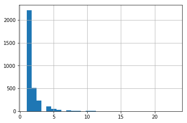

```python
# distribution of number of orders per customer in histogram
customerID_order.hist(bins=30)
```

## III. Delivery Performance

In terms of delivery performance, I analyzed both delivery time details, vehicle type analysis, and Jumpman relationship.

#### 1) Time breakdown of different stages of delivery shows:

- average time at pickup: 18 minutes
- average time on road: 14 minutes

It indicates that more time is spent at pickup locations than on road, we may need to have operation look for opportunities for cutting pickup time, so as to optimize Jumpman courier utilization rate, and also shortern customer wait time. Potential issues could be dispatching Jumpman too early to the pickup place before item is ready, or inefficiencies during Jumpman interaction with staff at pickup places.

```python
# check time breakdown of different stages of delivery
df_time=raw[['delivery_id','pickup_place','jumpman_id','vehicle_type',\
             'when_the_Jumpman_left_pickup','when_the_Jumpman_arrived_at_pickup',\
             'when_the_Jumpman_arrived_at_dropoff']].dropna()
print ('Analyze on %f percent valid time records with no missing value\n' %(len(df_time)/len(raw)))

df_time['time_at_pickup']=df_time['when_the_Jumpman_left_pickup']-df_time['when_the_Jumpman_arrived_at_pickup']
df_time['time_on_road']=df_time['when_the_Jumpman_arrived_at_dropoff']-df_time['when_the_Jumpman_left_pickup']
print ('average time at pickup is %f minutes' % (df_time['time_at_pickup'].mean().seconds/60))
print ('average time on road is %f minutes' % (df_time['time_on_road'].mean().seconds/60))
```

```
Analyze on 0.905063 percent valid time records with no missing value

average time at pickup is 18.283333 minutes
average time on road is 14.033333 minutes
```

#### 2) Deliveries conducted by different vehicle types

As shown in the table below, bikers and cars are top transportation mode used by Jumpman.

- Number of biker couriers are ~4 times of car drivers
- Bikers deliveries is about ~3.5 times car driver deliveries
- The bike mode is also faster, on average delivery time is ~4 mins shorter than car.

Given assumption that item quality won't change (food or drinks won't spill worse than car), bikes should continue to be considered as the most recommended courier transportation mode.

```python
#deliveries conducted by different vehicle types
#number of jumpman using different types of vehicles
jumpman_vehicle=df_time.groupby('vehicle_type').jumpman_id.nunique().reset_index().rename(columns={'jumpman_id':'jumpman_count'})
#number of deliveries finished by each types of vehicles
delivery_vehicle=df_time.groupby('vehicle_type').delivery_id.nunique().reset_index().rename(columns={'delivery_id':'delivery_count'})
#average time on road (efficiency) for vehicle types
time_vehicle=(df_time.groupby('vehicle_type').time_on_road.sum()/df_time.groupby('vehicle_type').time_on_road.count()).reset_index().rename(columns={'time_on_road':'average_time'})
vehicle_summary=jumpman_vehicle.merge(delivery_vehicle).merge(time_vehicle)
vehicle_summary
```

|  | vehicle_type | jumpman_count | delivery_count | average_time |
| --- | --- | --- | --- | --- |
| 0 | bicycle | 410 | 3373 | 00:13:04.964346 |
| 1 | car | 114 | 967 | 00:16:54.451118 |
| 2 | motorcycle | 4 | 18 | 00:12:42.139016 |
| 3 | scooter | 6 | 58 | 00:12:49.827885 |
| 4 | truck | 5 | 34 | 00:24:50.410877 |
| 5 | van | 8 | 60 | 00:16:45.143715 |
| 6 | walker | 18 | 209 | 00:14:10.213433 |

#### 3) Jumpman profile

The following table segmented Jumpman by number of orders they have delivered in the sample month. 71% Jumpman delivered up to 10 times on the platform, other 29% Jumpman are frequent couriers that deliver more than 10 times a month.

To reach supply-demand balance, (number of Jumpman * active time Jumpman stays on the app platform) should be able to satisfy customer delivery demand, while reaching reasonable Jumpman utilization rate so as to provide incentive for our Jumpman partners.

| delivery_count | jumpman_count | %_total_jumpman |
| --- | --- | --- |
| (0, 10] | 408 | 0.705882 |
| (10, 20] | 107 | 0.185121 |
| (20, 30] | 38 | 0.065744 |
| (40, 50] | 13 | 0.022491 |
| (30, 40] | 8 | 0.013841 |

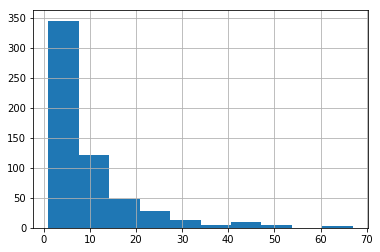

```python
# distribution of number of orders per Jumpman
JumpmanID_order=raw.groupby(['jumpman_id']).delivery_id.count() # Number of deliveries by jumpman id
JumpmanID_order.hist() #histogram
JumpmanID_order_count=pd.DataFrame(JumpmanID_order).rename(columns={'delivery_id':'delivery_count'}).reset_index()
Jumpman_loyalty_segment=JumpmanID_order_count.groupby(\
                        pd.cut(JumpmanID_order_count["delivery_count"], np.arange(0, 100, 10))).\
                        count().rename(columns={'jumpman_id':'jumpman_count'})[['jumpman_count']]
Jumpman_loyalty_segment
Jumpman_loyalty_segment['%_total_jumpman']=Jumpman_loyalty_segment.apply(lambda x:x/sum(x))
Jumpman_loyalty_segment.sort_values(by='%_total_jumpman',ascending=False).head()
```

### IV. Place Partnership

The following table shows 10 most popular places and 10 least popular places to order. Restuarant and grocery delivery are main items on demand, other non-food items are least ordered through Jumpman23.

It could due to lack of marketing exposure of non-food delivery services, small number of partnership Jumpman23 established with different product providers, or particular segment of customers Jumpman23 is missing when conducting customer acquisition. We need further data to investigate what is the exact reason, and provide actionable suggestions.

```python
place_order_count=raw.groupby(['place_category']).delivery_id.count().sort_values(ascending=False)
print ('10 most popular categories')
print (place_order_count.head(10))
```

```
10 most popular categories
place_category
Italian          437
Burger           395
American         357
Japanese         335
Dessert          277
Chinese          265
Sushi            203
Salad            192
Mexican          165
Grocery Store    130
Name: delivery_id, dtype: int64
```

```python
print ('\n10 least popular categories')
print (place_order_count.tail(10))
```

```
10 least popular categories
place_category
Specialty Store       5
German                4
Kids & Baby           3
Beauty Supply         2
Clothing              1
Book Store            1
Pet Supplies Store    1
Restaurant            1
Art Store             1
African               1
Name: delivery_id, dtype: int64
```

### Appendix: data preparation for tableau demand visual

```python
#geocode pickup and dropoff lat-lon for better visualization in tableau
reader = codecs.getreader("utf-8")
api_key='' #removed api key here for personal account privacy
def geocode(lat,lon):
    api = "https://maps.googleapis.com/maps/api/geocode/json?latlng="+str(lat)+","+str(lon)+"&key="+api_key
    reverseGeoCode = json.load(reader(urllib.request.urlopen(api)))
    zipcodelist=[k['long_name'] for k in reverseGeoCode['results'][0]['address_components'] if k['types'][0]=='postal_code']
    if zipcodelist==[]:
        zipcode='00000'
    else:
        zipcode=zipcodelist[0]
    return zipcode
```

```python
#For better visualization result. Tableau requires zipcode/block information, instead of just lat-lon
#There maybe a better resource than using google api for geo-coding latlon into zipcode, this is just a demo of technical capabilities
'''
latlon=raw[['delivery_id','pickup_lat','pickup_lon','dropoff_lat','dropoff_lon']]
f1=open('pickup_dropoff_geocode.csv','a')
f1.write('delivery_id,pickup_lat,pickup_lon,pickup_zipcode,dropoff_lat,dropoff_lon,dropoff_zipcode\n')
first=0
for i in range(len(latlon)):
    time.sleep(0.1)
    delivery_id=latlon.iloc[i,:][0]
    pickup_lat=latlon.iloc[i,:][1]
    pickup_lon=latlon.iloc[i,:][2]
    pickup_zipcode=geocode(pickup_lat,pickup_lon)
    dropoff_lat=latlon.iloc[i,:][3]
    dropoff_lon=latlon.iloc[i,:][4]
    dropoff_zipcode=geocode(dropoff_lat,dropoff_lon)
    f1.write(','.join([str(delivery_id),str(pickup_lat),str(pickup_lon),pickup_zipcode,str(dropoff_lat),str(dropoff_lon),dropoff_zipcode])+'\n')

f1.close()
'''
```

[output not shown]

```python
#merge geo-code data with original dataset
geocode=pd.read_csv('./data/pickup_dropoff_geocode.csv').drop_duplicates() # read the written geocode into pandas dataframe
delivery_zip=geocode.merge(raw,on='delivery_id',how='right') # delivery data with location zip code
delivery_zip.to_csv('./data/delivery_zip.csv')
```